# Rice-PCAs-SNPs

Aidan Angus-Henry

```r
library(tidyverse)
```

## Import the Data

```r
Sys.setenv(VROOM_CONNECTION_SIZE="500000") # needed because the lines in this file are very long.
data.geno <- read_csv("../input/Rice_44K_genotypes.csv.gz",
                      na=c("NA","00")) #missing data is denoted as "NA" or "00"
```

```
## ──────────────────────────────────────────────────────── Delimiter: "," chr
## (36902): ...1, 1_13147, 1_73192, 1_74969, 1_75852, 1_75953, 1_91016, 1_1...
```

```r
data.geno <- data.geno %>% select(-`6_17160794...22253`) # remove a duplicate column

head(data.geno)
```

```
## # A tibble: 6 × 36,901
##   ...1   `1_13147` `1_73192` `1_74969` `1_75852` `1_75953` `1_91016` `1_146625`
##   <chr>  <chr>     <chr>     <chr>     <chr>     <chr>     <chr>     <chr>
## 1 NSFTV1 TT        TT        CC        GG        TT        AA        CC
## 2 NSFTV3 CC        CC        CC        AA        GG        <NA>      CC
## 3 NSFTV4 CC        CC        CC        AA        GG        GG        CC
## 4 NSFTV5 CC        CC        TT        GG        GG        AA        TT
## 5 NSFTV6 CC        CC        CC        AA        GG        GG        CC
## 6 NSFTV7 TT        TT        CC        GG        TT        AA        CC
## # … with 36,893 more variables: `1_149005` <chr>, `1_149754` <chr>,
## #   `1_151492` <chr>, `1_152899` <chr>, `1_172755` <chr>, `1_172923` <chr>,
## #   `1_173692` <chr>, `1_195327` <chr>, `1_199011` <chr>, `1_202999` <chr>,
## #   `1_203126` <chr>, `1_205867` <chr>, `1_212693` <chr>, `1_212714` <chr>,
## #   `1_257707` <chr>, `1_260829` <chr>, `1_263568` <chr>, `1_263620` <chr>,
## #   `1_266818` <chr>, `1_267840` <chr>, `1_293504` <chr>, `1_320576` <chr>,
## #   `1_325596` <chr>, `1_327764` <chr>, `1_330743` <chr>, `1_334191` <chr>, …
```

```r
data.geno <- data.geno %>% rename(ID=...1) # Rename the first column to ID
```

## Construct PCA Plot

*Due to the size of the dataset, a randomly selected subset of 10k SNPs will be used* (I will soon modify this to use the full dataset)

```r
set.seed(0421)
data <- data.geno[,sample(2:ncol(data.geno), 10000)] # Subset the data
id <- select(data.geno, ID) # Extract the ID column
data.geno.10k <- data.frame(id, data) # Combine the ID column and 10k SNP subset
dim(data.geno.10k)
```

```
## [1]   413 10001
```

Convert the data matrix to numbers

```r
geno.numeric <- data.geno.10k[,-1] %>% # -1 to remove the first column, with names.
  lapply(factor) %>% # convert characters to "factors", where each category is internally represented as a number
  as.data.frame() %>% # reformat
  data.matrix() #  convert to numeric

head(geno.numeric[,1:10])
```

```
##      X2_29698250 X6_1585457 X3_27978687 X6_25059475 X8_27371587 X11_25311124
## [1,]           2          1           1           2           3            2
## [2,]           1          2           1           1           1            1
## [3,]           2          2           1           1           1            1
## [4,]           2          1           1           2           3            1
## [5,]           2          2           1           1           1            1
## [6,]           2          2           1           2           3            1
##      X2_28902044 X6_1388471 X2_573971 X5_3326806
## [1,]           1          2         1          1
## [2,]           2          2         1          2
## [3,]           2          2         1          1
## [4,]           2          2         1          1
## [5,]           2          2         1          1
## [6,]           2          2         1          1
```

Fill in missing data with average genotype

```r
geno.numeric.fill <-
  apply(geno.numeric, 2, function(x) {
    x[is.na(x)] <- mean(x, na.rm=T)
    x})
```

```r
geno.pca <- prcomp(geno.numeric.fill,
            rank.=10) # Compute the PCs, return the first 10

str(geno.pca)
```

```
## List of 5
##  $ sdev    : num [1:413] 32.14 13.59 12.9 7.36 6.12 ...
##  $ rotation: num [1:10000, 1:10] -0.0127 0.01105 0.00136 -0.01323 -0.02764 ...
##   ..- attr(*, "dimnames")=List of 2
##   .. ..$ : chr [1:10000] "X2_29698250" "X6_1585457" "X3_27978687" "X6_25059475" ...
##   .. ..$ : chr [1:10] "PC1" "PC2" "PC3" "PC4" ...
##  $ center  : Named num [1:10000] 1.65 1.4 1.04 1.65 2.24 ...
##   ..- attr(*, "names")= chr [1:10000] "X2_29698250" "X6_1585457" "X3_27978687" "X6_25059475" ...
##  $ scale   : logi FALSE
##  $ x       : num [1:413, 1:10] -31.87 47.09 36.45 -5.21 34.64 ...
##   ..- attr(*, "dimnames")=List of 2
##   .. ..$ : NULL
##   .. ..$ : chr [1:10] "PC1" "PC2" "PC3" "PC4" ...
##  - attr(*, "class")= chr "prcomp"
```

```r
head(geno.pca$x)[,1:5] # View the first 5 PCs
```

```
##             PC1        PC2        PC3        PC4        PC5
## [1,] -31.866245  -2.600177 -19.781436 -0.7762284  0.5874255
## [2,]  47.093731  19.425970  -4.505363  0.5562993 -3.9358199
## [3,]  36.451645 -21.550699   3.306038 -6.5773335 -0.5060249
## [4,]  -5.209656  -8.359672   4.242369 39.9799119 -0.2652907
## [5,]  34.637319 -21.057452   3.660483 -6.6301430  0.5810082
## [6,] -18.844062   2.748155  18.229538 -0.9273680 -0.8647676
```

Determine proportion of variance explained by each PC:

```r
pcvar <- geno.pca$sdev^2 # square std dev to get variance
pcvar.pct <- tibble(pctvar=pcvar/sum(pcvar) * 100,
                    PC=1:length(pcvar))

head(pcvar.pct)
```

```
## # A tibble: 6 × 2
##   pctvar    PC
##    <dbl> <int>
## 1  43.4      1
## 2   7.75     2
## 3   6.98     3
## 4   2.27     4
## 5   1.57     5
## 6   1.14     6
```

Plot the proportion of variance covered by each PC

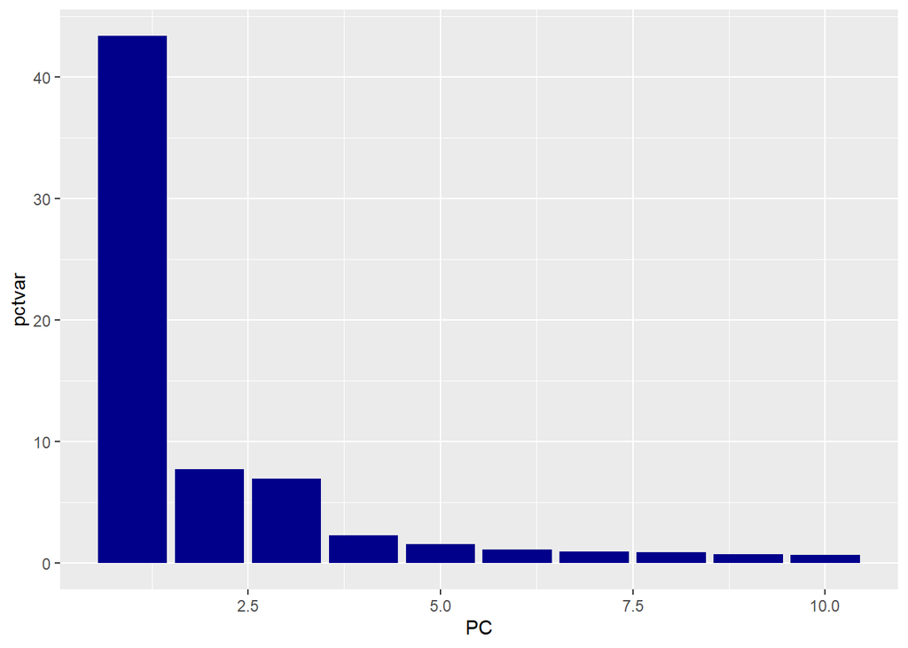

```r
pcvar.pct[1:10,] %>%
  ggplot(mapping = aes(x=PC, y=pctvar)) +
  geom_col(fill="darkblue")
```

Make a tibble with the PCs and IDs

```r
PCs <- as_tibble(geno.pca$x) %>% # The calculated PCs
  mutate(ID=data.geno.10k$ID) %>%
  select(ID, everything())

head(PCs)
```

```
## # A tibble: 6 × 11
##   ID        PC1    PC2    PC3    PC4    PC5     PC6     PC7    PC8     PC9  PC10
##   <chr>   <dbl>  <dbl>  <dbl>  <dbl>  <dbl>   <dbl>   <dbl>  <dbl>   <dbl> <dbl>
## 1 NSFTV1 -31.9   -2.60 -19.8  -0.776  0.587  -0.293   0.187 -0.819   0.288 -2.13
## 2 NSFTV3  47.1   19.4   -4.51  0.556 -3.94  -13.6     4.31  -1.21    1.41  -1.54
## 3 NSFTV4  36.5  -21.6    3.31 -6.58  -0.506  -4.81  -13.4    4.77  -17.8   -4.76
## 4 NSFTV5  -5.21  -8.36   4.24 40.0   -0.265   0.249  -1.30   4.40   -0.384  1.07
## 5 NSFTV6  34.6  -21.1    3.66 -6.63   0.581  -5.85  -15.2    5.11  -19.9   -5.57
## 6 NSFTV7 -18.8    2.75  18.2  -0.927 -0.865   0.527  -0.801  0.125  -1.93   1.64
```

## PC and MDS Plots

Plot the PCs

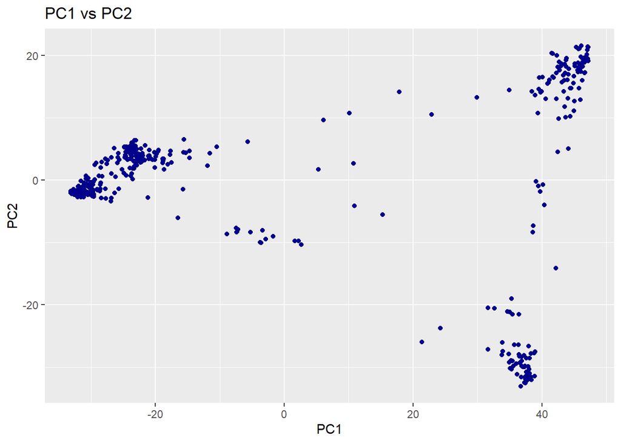

```r
PCs %>%
  ggplot(mapping = aes(x=PC1, y=PC2)) +
  labs(title="PC1 vs PC2") +
  geom_point(color="darkblue")
```

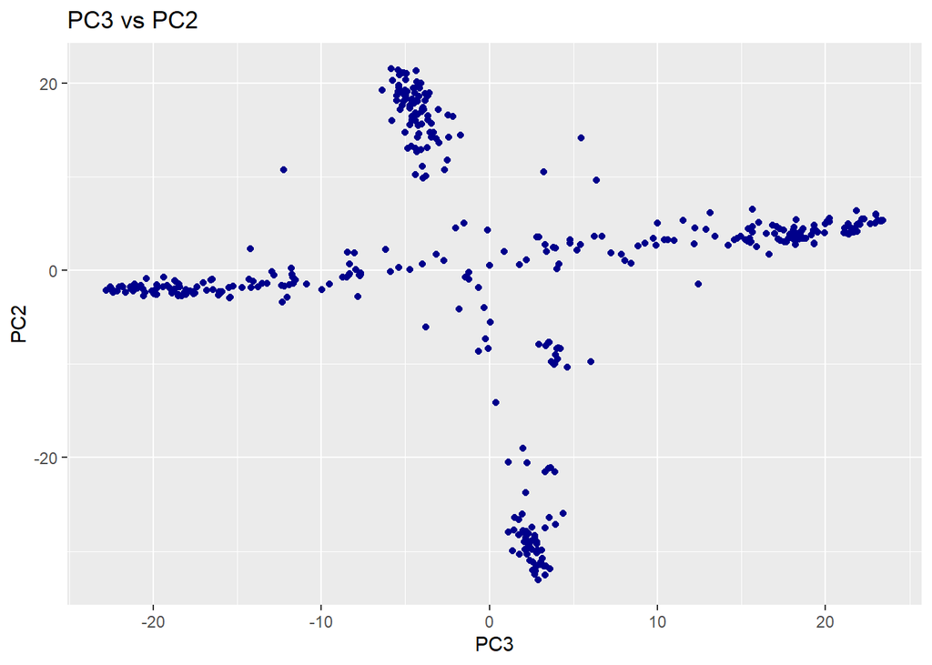

```r
PCs %>%
  ggplot(mapping = aes(x=PC3, y=PC2)) +
  labs(title="PC3 vs PC2") +
  geom_point(color="darkblue")
```

Make an MDS Plot

```r
# calculate the Euclidian distance between each rice variety
genDist <- as.matrix(dist(geno.numeric))

# perform multi-dimensional scaling
geno.mds <- as_tibble(cmdscale(genDist))
# Add the variety ID back into this
geno.mds$ID <- data.geno.10k$ID
head(geno.mds) #now we have 2 dimensions + the ID
```

```
## # A tibble: 6 × 3
##       V1     V2 ID
##    <dbl>  <dbl> <chr>
## 1  33.0   -1.71 NSFTV1
## 2 -48.5   20.5  NSFTV3
## 3 -37.4  -22.5  NSFTV4
## 4   5.96  -8.98 NSFTV5
## 5 -35.9  -22.2  NSFTV6
## 6  19.8    1.92 NSFTV7
```

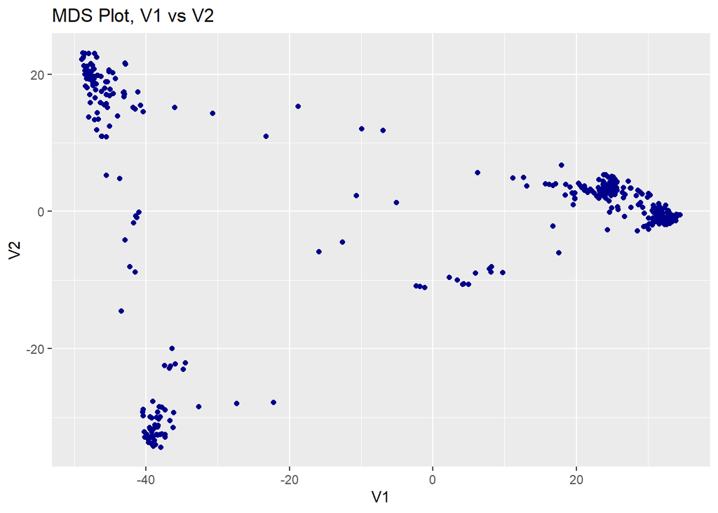

```r
# Plot V1 vs V2
geno.mds %>%
  ggplot(mapping = aes(x=V1, y=V2)) +
  labs(title = "MDS Plot, V1 vs V2") +
  geom_point(color="darkblue")
```

*The PCA and MDS plots suggest the existence of at least 3 sub. populations*

## Add Phenotype data

```r
data.pheno <- read_csv("../input/RiceDiversity.44K.MSU6.Phenotypes.csv")
head(data.pheno)
```

```
## # A tibble: 6 × 39
##   NSFTVID Accession_Name Country_of_Origin Region  Alu.Tol `Flowering time at …`
##   <chr>   <chr>          <chr>             <chr>     <dbl>                 <dbl>
## 1 NSFTV1  Agostano       Italy             Europe     0.73                  75.1
## 2 NSFTV3  Ai-Chiao-Hong  China             E Asia     0.3                   89.5
## 3 NSFTV4  NSF-TV 4       Unknown           <NA>       0.54                  94.5
## 4 NSFTV5  NSF-TV 5       Unknown           <NA>       0.44                  87.5
## 5 NSFTV6  ARC 7229       India             S Asia     0.57                  89.1
## 6 NSFTV7  Arias          Indonesia         Pacific    0.86                 105
## # … with 33 more variables: `Flowering time at Faridpur` <dbl>,
## #   `Flowering time at Aberdeen` <dbl>, `FT ratio of Arkansas/Aberdeen` <dbl>,
## #   `FT ratio of Faridpur/Aberdeen` <dbl>, `Culm habit` <dbl>,
## #   `Leaf pubescence` <dbl>, `Flag leaf length` <dbl>, `Flag leaf width` <dbl>,
## #   `Awn presence` <dbl>, `Panicle number per plant` <dbl>,
## #   `Plant height` <dbl>, `Panicle length` <dbl>,
## #   `Primary panicle branch number` <dbl>, `Seed number per panicle` <dbl>, …
```

```r
data.pheno.pca <- inner_join(PCs, data.pheno, by=c("ID"="NSFTVID"))
summary(data.pheno.pca)
```

```
##       ID                 PC1              PC2               PC3
##  Length:413         Min.   :-33.17   Min.   :-33.036   Min.   :-22.8146
##  Class :character   1st Qu.:-28.34   1st Qu.: -2.267   1st Qu.: -7.7414
##  Mode  :character   Median :-20.97   Median :  2.034   Median : -0.6491
##                     Mean   :  0.00   Mean   :  0.000   Mean   :  0.0000
##                     3rd Qu.: 37.93   3rd Qu.:  5.285   3rd Qu.:  8.4259
##                     Max.   : 47.19   Max.   : 21.557   Max.   : 23.4054
##
##       PC4               PC5               PC6                 PC7
##  Min.   :-6.6301   Min.   :-13.985   Min.   :-17.01207   Min.   :-15.2263
##  1st Qu.:-2.7487   1st Qu.: -2.337   1st Qu.: -1.46168   1st Qu.: -1.8416
##  Median :-1.3759   Median : -0.318   Median : -0.05271   Median :  0.1913
##  Mean   : 0.0000   Mean   :  0.000   Mean   :  0.00000   Mean   :  0.0000
##  3rd Qu.: 0.2568   3rd Qu.:  1.202   3rd Qu.:  1.65999   3rd Qu.:  1.7192
##  Max.   :40.4578   Max.   : 22.297   Max.   : 16.18669   Max.   : 22.6003
##
##       PC8                PC9                PC10            Accession_Name
##  Min.   :-16.7598   Min.   :-19.8945   Min.   :-10.758691   Length:413
##  1st Qu.: -2.6039   1st Qu.: -0.9065   1st Qu.: -2.257464   Class :character
##  Median :  0.1164   Median :  0.1551   Median : -0.007041   Mode  :character
##  Mean   :  0.0000   Mean   :  0.0000   Mean   :  0.000000
##  3rd Qu.:  3.3112   3rd Qu.:  1.1206   3rd Qu.:  2.642141
##  Max.   : 12.1299   Max.   : 17.7734   Max.   : 12.556772
##
##  Country_of_Origin     Region             Alu.Tol
##  Length:413         Length:413         Min.   :0.0300
##  Class :character   Class :character   1st Qu.:0.4000
##  Mode  :character   Mode  :character   Median :0.6035
##                                        Mean   :0.5874
##                                        3rd Qu.:0.7500
##                                        Max.   :1.3500
##                                        NA's   :43
##  Flowering time at Arkansas Flowering time at Faridpur
##  Min.   : 54.50             Min.   : 39.00
##  1st Qu.: 79.75             1st Qu.: 66.00
##  Median : 87.71             Median : 74.00
##  Mean   : 87.94             Mean   : 71.77
##  3rd Qu.: 96.83             3rd Qu.: 78.00
##  Max.   :150.50             Max.   :110.00
##  NA's   :39                 NA's   :108
```

[output cut: 65 more lines]

```
##  Length:413         Min.   :2.330              Min.   :0.000    Min.   : 0.00
##  Class :character   1st Qu.:5.998              1st Qu.:2.000    1st Qu.:16.70
##  Mode  :character   Median :7.165              Median :5.000    Median :21.13
##                     Mean   :6.936              Mean   :5.039    Mean   :19.88
##                     3rd Qu.:8.167              3rd Qu.:8.000    3rd Qu.:23.97
##                     Max.   :9.000              Max.   :9.000    Max.   :27.96
##                     NA's   :73                 NA's   :28       NA's   :12
##  Alkali spreading value Protein content
##  Min.   :2.000          Min.   : 6.500
##  1st Qu.:5.403          1st Qu.: 7.950
##  Median :6.083          Median : 8.450
##  Mean   :5.974          Mean   : 8.593
##  3rd Qu.:6.938          3rd Qu.: 9.050
##  Max.   :7.000          Max.   :14.100
##  NA's   :10             NA's   :20
```

Color the PCA plots by different phenotypes

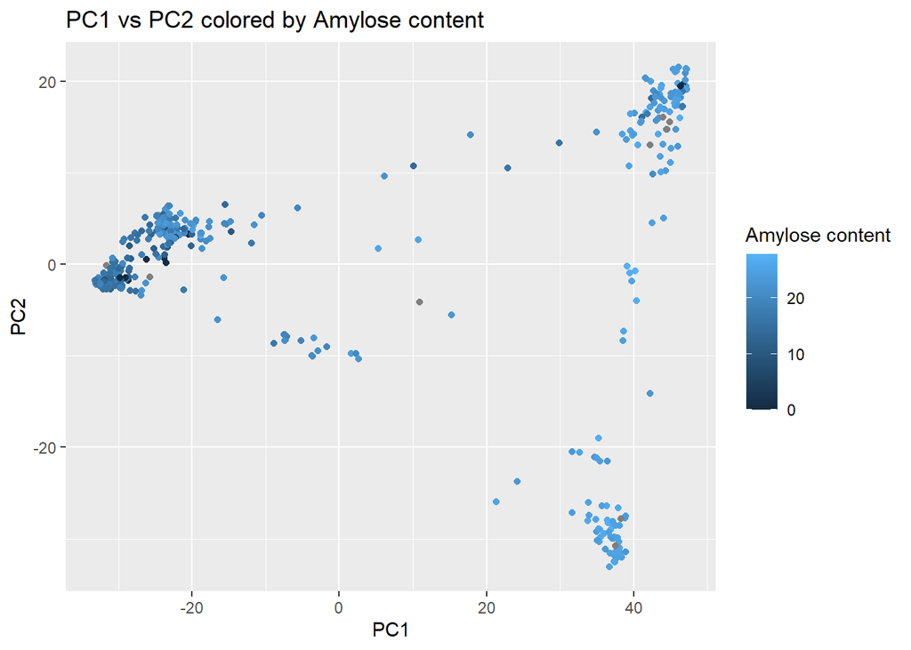

```r
# Color PCA plot by Amylose content

data.pheno.pca %>%
  ggplot(mapping = aes(x=PC1, y=PC2, color=`Amylose content`)) +
  labs(title = "PC1 vs PC2 colored by Amylose content") +
  geom_point()
```

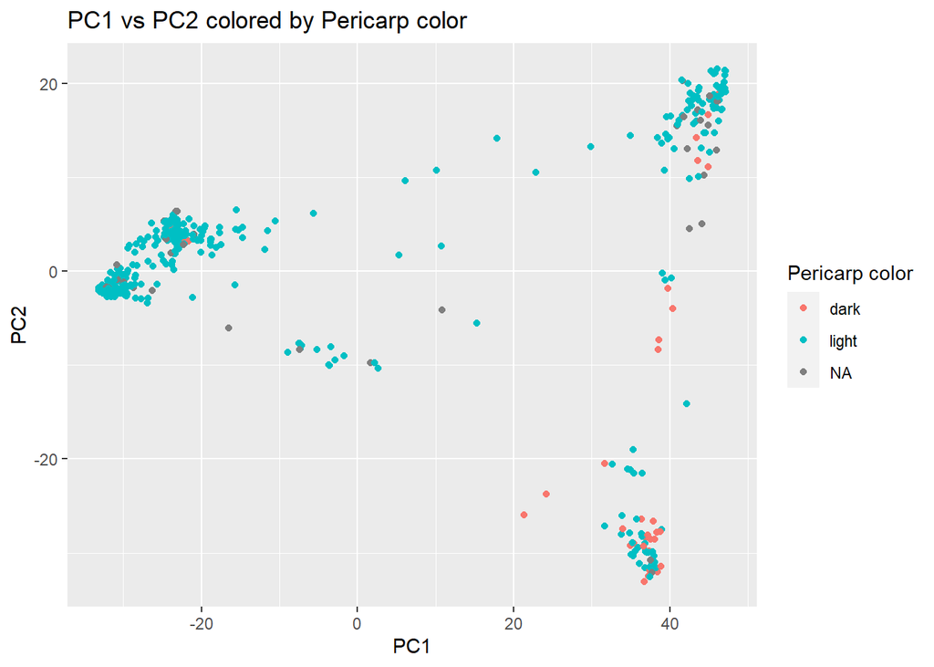

```r
# Color PCA plot by pericarp color
data.pheno.pca %>%
  ggplot(mapping = aes(x=PC1, y=PC2, color=`Pericarp color`)) +
  labs(title = "PC1 vs PC2 colored by Pericarp color") +
  geom_point()
```

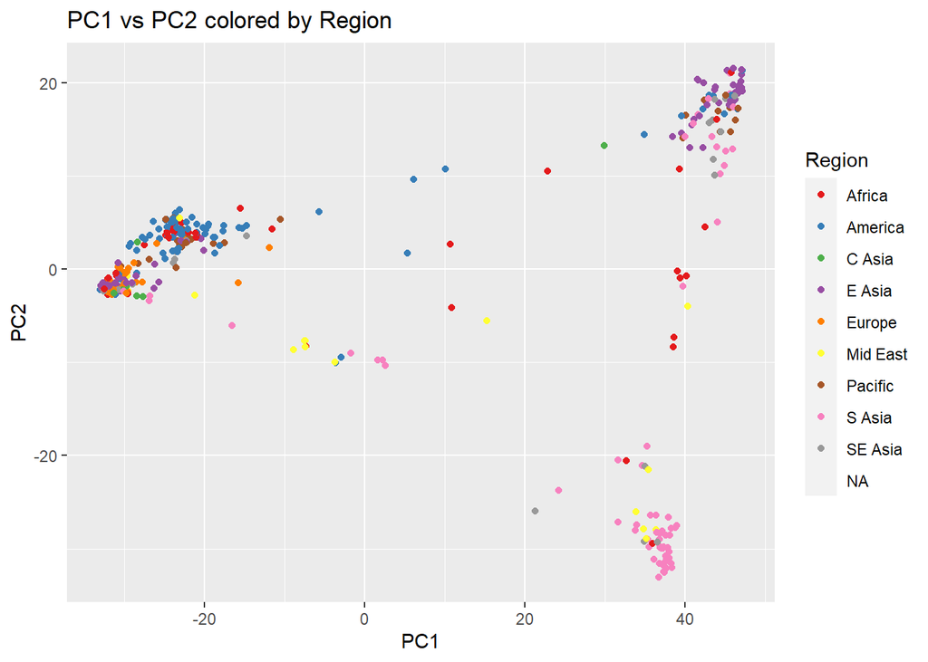

```r
# Color PCA plot by Region
data.pheno.pca %>%
  ggplot(mapping = aes(x=PC1, y=PC2, color=`Region`)) +
  labs(title = "PC1 vs PC2 colored by Region") +
  scale_color_brewer(type="qual", palette = "Set1") +
  geom_point()
```

## Population assignments with fastStructure

Create the genotype file

```r
# Create a new Matrix to hold reformatted data
data.geno.10k.fs <- matrix("",nrow=nrow(data.geno.10k)*2,ncol=ncol(data.geno.10k)-1+6)

# for each row of genotypes, create 2 rows, one with the first allele and one with the second allele.
# also, fill the first 6 columns with the strain ID (could also be blank but we need something there)
for (i in 1:nrow(data.geno.10k)) {
  data.geno.10k.fs[(i-1)*2+1,1:6] <- data.geno.10k[[i,1]]
  data.geno.10k.fs[(i-1)*2+2,1:6] <- data.geno.10k[[i,1]]
  data.geno.10k.fs[(i-1)*2+1,-1:-6] <- substr(data.geno.10k[i,-1],1,1)
  data.geno.10k.fs[(i-1)*2+2,-1:-6] <- substr(data.geno.10k[i,-1],2,2)
}

data.geno.10k.fs[is.na(data.geno.10k.fs)] <- -9 # fastStructure's code for missing data

dim(data.geno.10k.fs)
```

```
## [1]   826 10006
```

```r
# look at the data
data.geno.10k.fs[1:10,1:10]
```

```
##       [,1]     [,2]     [,3]     [,4]     [,5]     [,6]     [,7] [,8] [,9]
##  [1,] "NSFTV1" "NSFTV1" "NSFTV1" "NSFTV1" "NSFTV1" "NSFTV1" "G"  "A"  "C"
##  [2,] "NSFTV1" "NSFTV1" "NSFTV1" "NSFTV1" "NSFTV1" "NSFTV1" "G"  "A"  "C"
##  [3,] "NSFTV3" "NSFTV3" "NSFTV3" "NSFTV3" "NSFTV3" "NSFTV3" "C"  "G"  "C"
##  [4,] "NSFTV3" "NSFTV3" "NSFTV3" "NSFTV3" "NSFTV3" "NSFTV3" "C"  "G"  "C"
##  [5,] "NSFTV4" "NSFTV4" "NSFTV4" "NSFTV4" "NSFTV4" "NSFTV4" "G"  "G"  "C"
##  [6,] "NSFTV4" "NSFTV4" "NSFTV4" "NSFTV4" "NSFTV4" "NSFTV4" "G"  "G"  "C"
##  [7,] "NSFTV5" "NSFTV5" "NSFTV5" "NSFTV5" "NSFTV5" "NSFTV5" "G"  "A"  "C"
##  [8,] "NSFTV5" "NSFTV5" "NSFTV5" "NSFTV5" "NSFTV5" "NSFTV5" "G"  "A"  "C"
##  [9,] "NSFTV6" "NSFTV6" "NSFTV6" "NSFTV6" "NSFTV6" "NSFTV6" "G"  "G"  "C"
## [10,] "NSFTV6" "NSFTV6" "NSFTV6" "NSFTV6" "NSFTV6" "NSFTV6" "G"  "G"  "C"
##       [,10]
##  [1,] "C"
##  [2,] "C"
##  [3,] "A"
##  [4,] "A"
##  [5,] "A"
##  [6,] "A"
##  [7,] "C"
##  [8,] "C"
##  [9,] "A"
## [10,] "A"
```

```r
write.table(data.geno.10k.fs,file="../output/rice.data.fastStructure.input.str", col.names = FALSE, row.names = FALSE, quote = FALSE)
```

Create the .fam file

```r
fam <- tibble(
  FID=data.geno.10k$ID,
  IID=data.geno.10k$ID,
  PID=0,
  MID=0,
  Sex=0,
  Ptype=-9)

head(fam)
```

```
## # A tibble: 6 × 6
##   FID    IID      PID   MID   Sex Ptype
##   <chr>  <chr>  <dbl> <dbl> <dbl> <dbl>
## 1 NSFTV1 NSFTV1     0     0     0    -9
## 2 NSFTV3 NSFTV3     0     0     0    -9
## 3 NSFTV4 NSFTV4     0     0     0    -9
## 4 NSFTV5 NSFTV5     0     0     0    -9
## 5 NSFTV6 NSFTV6     0     0     0    -9
## 6 NSFTV7 NSFTV7     0     0     0    -9
```

```r
write.table(fam,file="../output/rice.data.fastStructure.input.fam",col.names = FALSE, row.names = FALSE, quote = FALSE)
```

Create the .bim file

```r
bim <- data.geno.10k.fs[,-1:-6]

colnames(bim) <- colnames(data.geno.10k)[-1]

bim[bim=="-9"] <- NA

bim <- apply(bim,2,function(x) unique(na.omit(x)))

bim[,1:5]
```

```
##      X2_29698250 X6_1585457 X3_27978687 X6_25059475 X8_27371587
## [1,] "G"         "A"        "C"         "C"         "G"
## [2,] "C"         "G"        "T"         "A"         "A"
```

```r
bim <- t(bim) %>%  # t transposes the matrix
  as_tibble() %>%
  mutate(SNP_ID=colnames(bim), cM=0)

head(bim) # now have a table where each row is a SNP
```

```
## # A tibble: 6 × 4
##   V1    V2    SNP_ID          cM
##   <chr> <chr> <chr>        <dbl>
## 1 G     C     X2_29698250      0
## 2 A     G     X6_1585457       0
## 3 C     T     X3_27978687      0
## 4 C     A     X6_25059475      0
## 5 G     A     X8_27371587      0
## 6 G     A     X11_25311124     0
```

```r
# Separate SNP_ID to get chromosome and position

bim <- bim %>%
  separate(SNP_ID,into = c("chromosome","position"),sep="_",remove=FALSE) %>% # create a column for chromosome and position
  select(chromosome, SNP_ID, cM, position, allele1=V1, allele2=V2) # get columns in right order

head(bim)
```

```
## # A tibble: 6 × 6
##   chromosome SNP_ID          cM position allele1 allele2
##   <chr>      <chr>        <dbl> <chr>    <chr>   <chr>
## 1 X2         X2_29698250      0 29698250 G       C
## 2 X6         X6_1585457       0 1585457  A       G
## 3 X3         X3_27978687      0 27978687 C       T
## 4 X6         X6_25059475      0 25059475 C       A
## 5 X8         X8_27371587      0 27371587 G       A
## 6 X11        X11_25311124     0 25311124 G       A
```

```r
write.table(bim,file="../output/rice.data.fastStructure.input.bim",col.names = FALSE, row.names = FALSE, quote = FALSE)
```

## Running fastStructure

*Run on Ubuntu v. 20.04 via WSL*

The following bash code was executed within the fastStructure-master directory:

```
python structure.py -K 4 --input=/mnt/c/Users/aangu/bioinfo/bis180L/Rice-PCA-SNPs/output/rice.data.fastStructure.input --output=/mnt/c/Users/aangu/bioinfo/bis180L/Rice-PCA-SNPs/output/rice.fastStructure.out --format=str
```

## Processing fastStructure results

```r
fs_results <- read_delim("../output/rice.fastStructure.out.4.meanQ", delim="  ", col_names = FALSE, col_types = 'nnnn')
head(fs_results)
```

```
## # A tibble: 6 × 4
##         X1       X2       X3       X4
##      <dbl>    <dbl>    <dbl>    <dbl>
## 1 0.000014 0.000013 0.000013 1.00
## 2 0.000014 1.00     0.000014 0.000014
## 3 0.000014 0.131    0.869    0.000014
## 4 0.418    0.000014 0.335    0.247
## 5 0.000014 0.129    0.871    0.000014
## 6 0.953    0.000014 0.0475   0.000014
```

Add the sample IDs back and assign names to each pop.

```r
fs_results <- fs_results %>%
  mutate(ID=data.geno.10k$ID) %>%
  select(ID, pop1=X1, pop2=X2, pop3=X3, pop4=X4)
head(fs_results)
```

```
## # A tibble: 6 × 5
##   ID         pop1     pop2     pop3     pop4
##   <chr>     <dbl>    <dbl>    <dbl>    <dbl>
## 1 NSFTV1 0.000014 0.000013 0.000013 1.00
## 2 NSFTV3 0.000014 1.00     0.000014 0.000014
## 3 NSFTV4 0.000014 0.131    0.869    0.000014
## 4 NSFTV5 0.418    0.000014 0.335    0.247
## 5 NSFTV6 0.000014 0.129    0.871    0.000014
## 6 NSFTV7 0.953    0.000014 0.0475   0.000014
```

Assign each individual to a sub population based on fastStructure data

```r
fs_results$assignedPop <- apply(fs_results[,-1], 1, which.max)
head(fs_results)
```

```
## # A tibble: 6 × 6
##   ID         pop1     pop2     pop3     pop4 assignedPop
##   <chr>     <dbl>    <dbl>    <dbl>    <dbl>       <int>
## 1 NSFTV1 0.000014 0.000013 0.000013 1.00               4
## 2 NSFTV3 0.000014 1.00     0.000014 0.000014           2
## 3 NSFTV4 0.000014 0.131    0.869    0.000014           3
## 4 NSFTV5 0.418    0.000014 0.335    0.247              1
## 5 NSFTV6 0.000014 0.129    0.871    0.000014           3
## 6 NSFTV7 0.953    0.000014 0.0475   0.000014           1
```

Order samples based on sub pop. identity

```r
fs_results$maxPr <- apply(fs_results[,2:5],1,max)
fs_results <- fs_results %>%
  arrange(assignedPop,desc(maxPr)) %>%
  mutate(plot.order=row_number())

head(fs_results)
```

```
## # A tibble: 6 × 8
##   ID       pop1     pop2     pop3     pop4 assignedPop maxPr plot.order
##   <chr>   <dbl>    <dbl>    <dbl>    <dbl>       <int> <dbl>      <int>
## 1 NSFTV24  1.00 0.000013 0.000013 0.000013           1  1.00          1
## 2 NSFTV25  1.00 0.000013 0.000013 0.000014           1  1.00          2
## 3 NSFTV26  1.00 0.000013 0.000013 0.000013           1  1.00          3
## 4 NSFTV27  1.00 0.000013 0.000013 0.000014           1  1.00          4
## 5 NSFTV46  1.00 0.000013 0.000013 0.000014           1  1.00          5
## 6 NSFTV65  1.00 0.000013 0.000013 0.000014           1  1.00          6
```

Convert the data to long format

```r
fs_results_long <- fs_results %>% pivot_longer(pop1:pop4,
                                               names_to="population",
                                               values_to="proportion")
head(fs_results_long)
```

```
## # A tibble: 6 × 6
##   ID      assignedPop maxPr plot.order population proportion
##   <chr>         <int> <dbl>      <int> <chr>           <dbl>
## 1 NSFTV24           1  1.00          1 pop1         1.00
## 2 NSFTV24           1  1.00          1 pop2         0.000013
## 3 NSFTV24           1  1.00          1 pop3         0.000013
## 4 NSFTV24           1  1.00          1 pop4         0.000013
## 5 NSFTV25           1  1.00          2 pop1         1.00
## 6 NSFTV25           1  1.00          2 pop2         0.000013
```

## Plot the fastStructure results

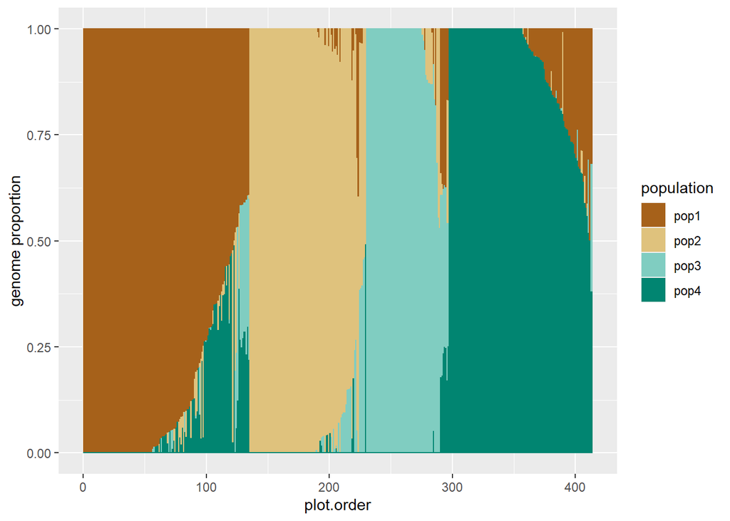

```r
fs_results_long %>%
  ggplot(aes(x=plot.order, y=proportion, color=population, fill=population)) +
  geom_col()  +
  ylab("genome proportion") +
  scale_color_brewer(type="div") + scale_fill_brewer(type="div")
```

##### Compare sub pop. assignments to the PCA plots

Combine the PC data with the fastStructure data

```r
fs_results <- fs_results %>% mutate(assignedPop=as.character(assignedPop))

geno.pca.pop <- inner_join(fs_results, PCs, by="ID")
```

PCA plots colored by sub pop.

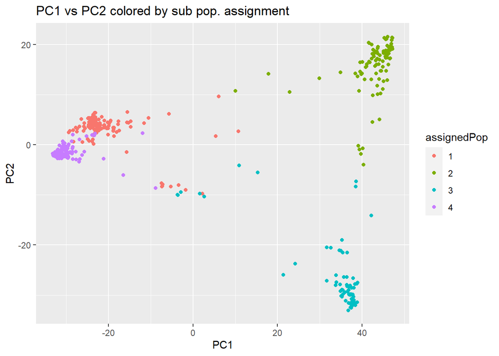

```r
# PC1 vs PC2
geno.pca.pop %>% ggplot(mapping = aes(x=PC1, y=PC2, color=assignedPop)) +
  labs(title="PC1 vs PC2 colored by sub pop. assignment") +
  geom_point()
```

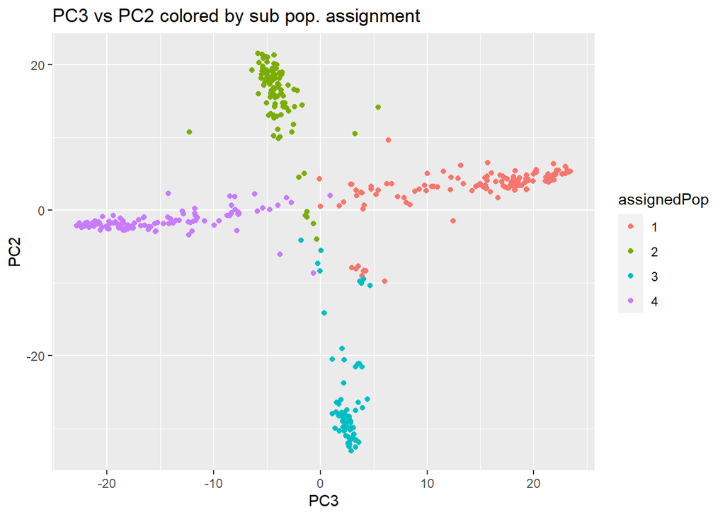

```r
# PC2 vs PC3
geno.pca.pop %>% ggplot(mapping = aes(x=PC3, y=PC2, color=assignedPop)) +
  labs(title="PC3 vs PC2 colored by sub pop. assignment") +
  geom_point()
```

Save some of the objects created

```r
save(data.pheno,geno.pca, PCs, geno.pca.pop,fs_results,file="../output/data_from_SNP_lab.Rdata")
```